# Appendix 4: Documentation of Code

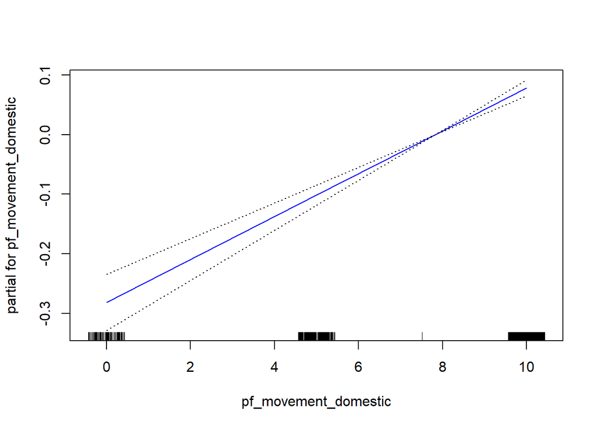

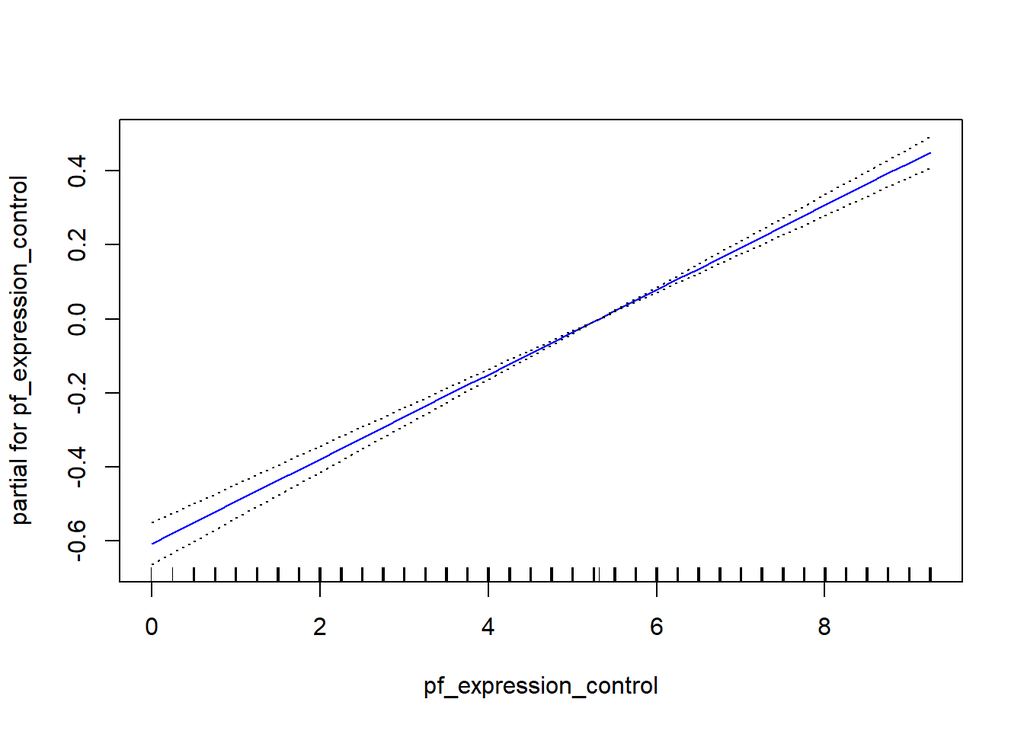

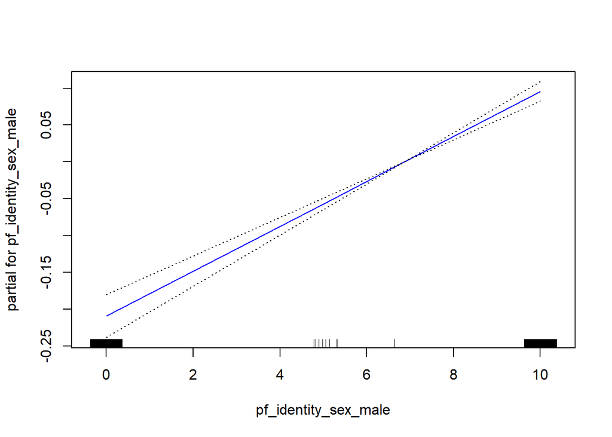

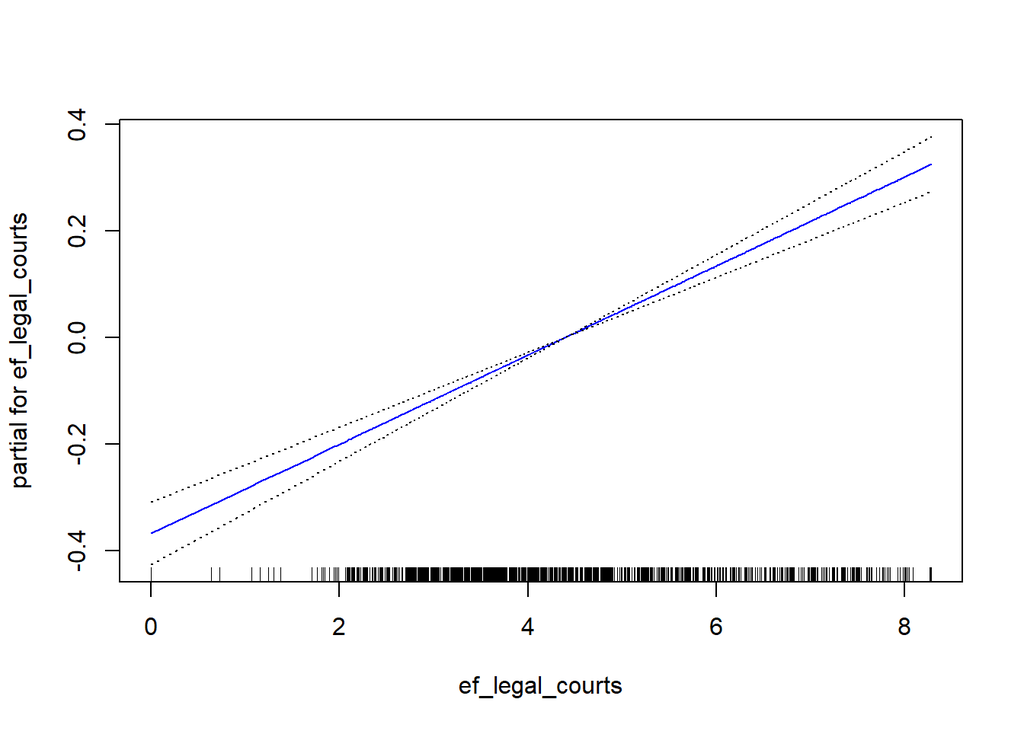

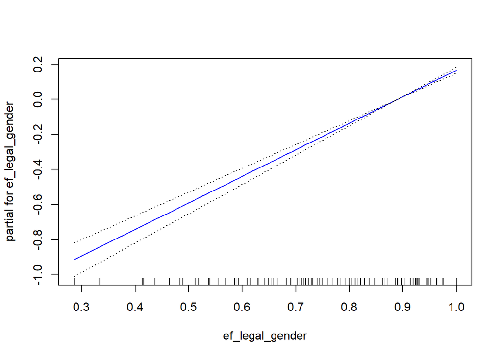

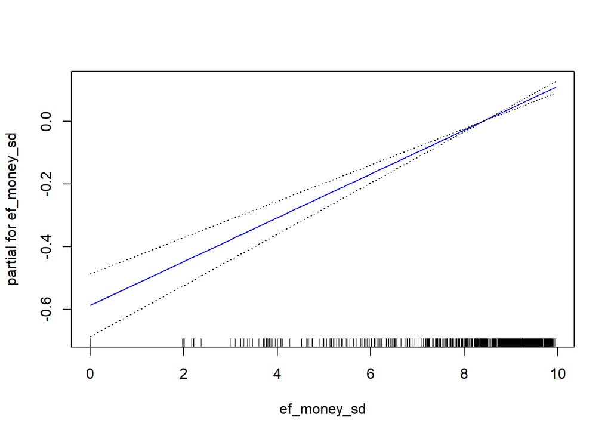

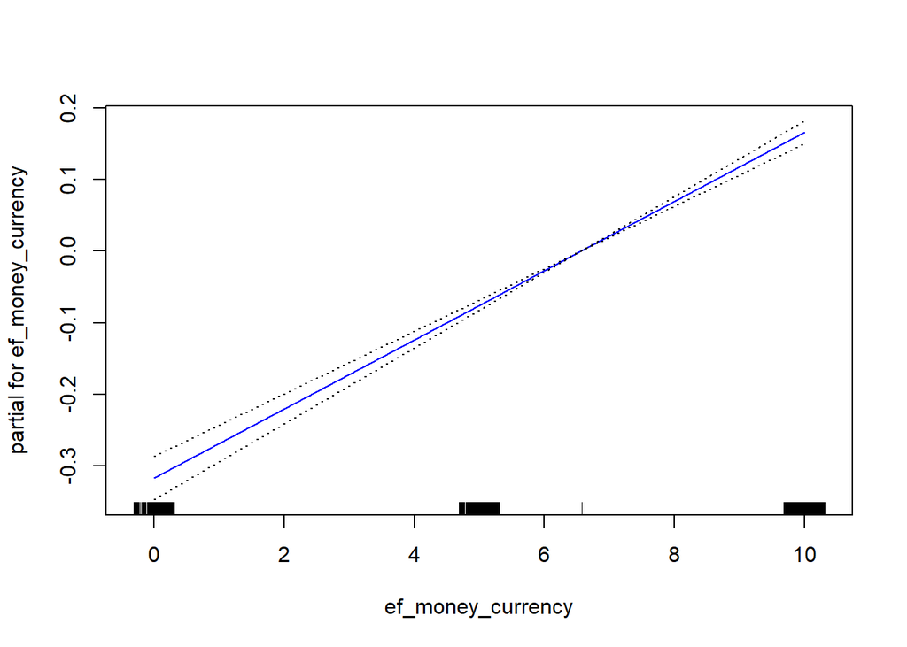

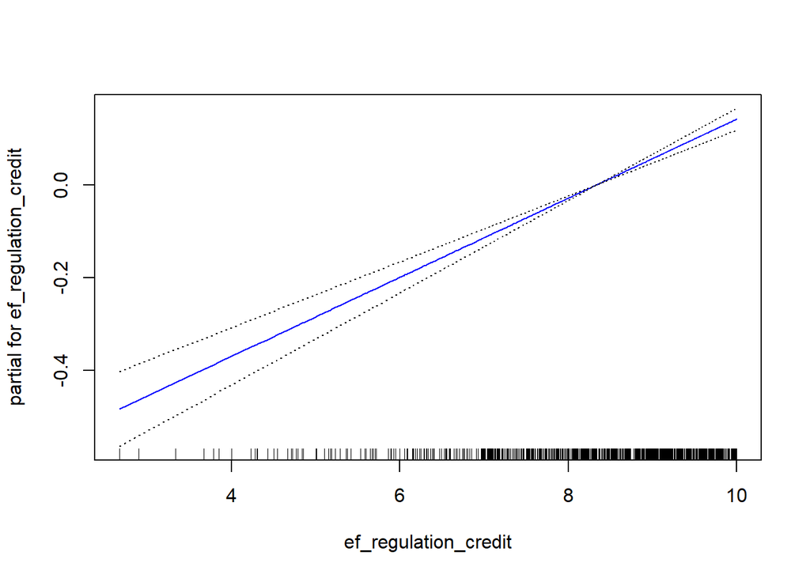

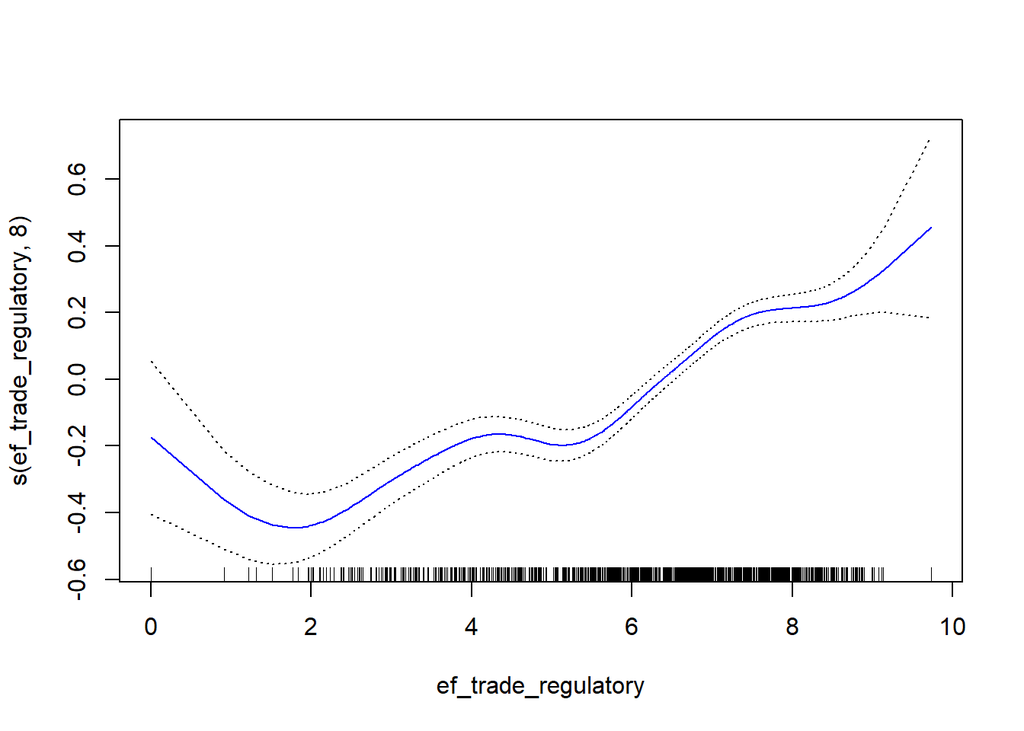

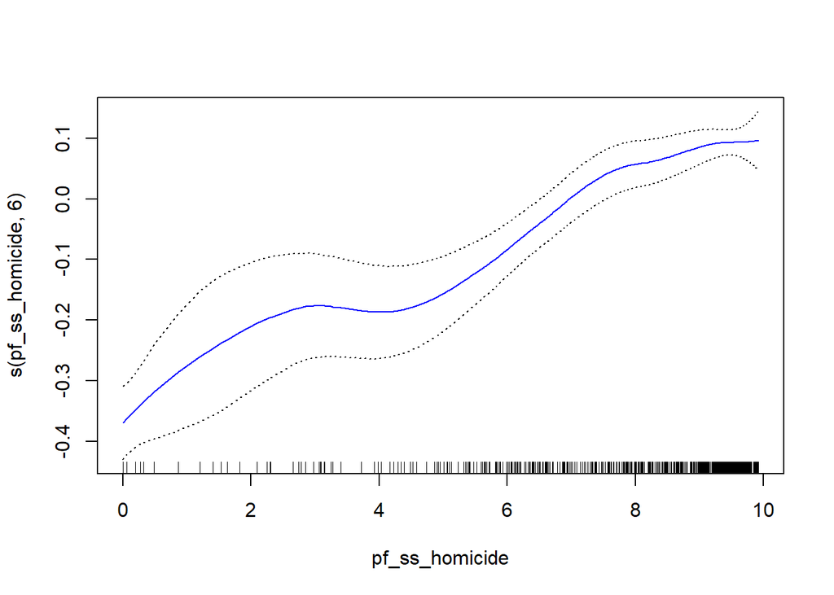

```r
set.seed(111)
gam1= gam(hf_score ~ pf_movement_domestic+
                pf_expression_control+
                pf_identity_sex_male+
                ef_legal_courts+
                ef_legal_gender+
                ef_money_sd+
                ef_money_currency+
                ef_regulation_credit+
               s(ef_trade_regulatory ,8)+
               s(pf_ss_homicide,6),data=hfi.combined.train)
plot(gam1, se=TRUE ,col =" blue")
```

```r
preds=predict (gam1, newdata = hfi.combined.test)
testMSE.smoothspline = mean((hfi.combined.test$hf_score - preds)^2)
testMSE.smoothspline
```

```
## [1] 0.07196904
```

```r
fit14=testMSE.smoothspline
TSS <- mean((hfi.combined.test$hf_score - mean(hfi.combined.test$hf_score))^2)
Rsquared.smoothspline <- 1 - testMSE.smoothspline / TSS
Rsquared.smoothspline
```

```
## [1] 0.9184843
```

The cubic Smoothing Spline GAM yields a test MSE of 0.071969, which is very similar to the 10-fold CV error rates of the polynomial regression with 10 predictors (0.0771709), as well as the natural cubic spline GAM (0.0770118).

## 4.4 KNN Regression

```r
set.seed(111)
# var to select number of groups to split data into for CV
kfold.number = 10
# the greatest 'K' KNN will run (no point going higher than 20 ...)
top_k = 20
# average of the Cross-Validated test errors
avg_mse_knn = rep(0, top_k)

# this randomly assigns a 'group k' to each observation
hfi.combined$groups =  sample(rep(1:kfold.number, 200)) %>%
  head(nrow(hfi.combined))

# now iterate for ALL 3 through top_k as the 'K' in KNN
# Starts at 3 because it does not seem to work with only
# 1 or 2 as the K (do not know why...)
for (k in 3:top_k) {
  # vector of the MSEs for current KNN.Regression
  mse_list_knn = rep(0, kfold.number)
  for (i in 1:kfold.number){
    # split into test and train set depending on i (i == test group)
    test_set = hfi.combined %>% filter(groups == i)
    test_res = test_set %>% dplyr::select(hf_score)
    test_set = test_set %>% dplyr::select(-c(hf_score, groups))

    train_set = hfi.combined %>% filter(groups != i)
    train_res = train_set %>% dplyr::select(hf_score)
    train_set = train_set %>% dplyr::select(-c(hf_score, groups))

    # predict and calculate the MSE
    preds = knn.reg(train = train_set, test = test_set, y = train_res, k = k)
    mse_list_knn[i] = mean((test_res$hf_score - preds$pred)^2)
  }
  # take average of all top_k MSE's gathered
  avg_mse_knn[k] = mean(mse_list_knn)
}

# print the MSE's
for (i in 1:(length(avg_mse_knn)-2)){
  string.to.print = paste( "K: ", i+2, "; (10-Fold CV Error): ", avg_mse_knn[i+2])
  print(string.to.print)
}
```

```
## [1] "K:  3 ; (10-Fold CV Error):  0.0313274200581256"
## [1] "K:  4 ; (10-Fold CV Error):  0.0369596140881826"
## [1] "K:  5 ; (10-Fold CV Error):  0.0410325480221336"
## [1] "K:  6 ; (10-Fold CV Error):  0.0466502516002375"
## [1] "K:  7 ; (10-Fold CV Error):  0.0517116159889283"
## [1] "K:  8 ; (10-Fold CV Error):  0.0567495440842898"
## [1] "K:  9 ; (10-Fold CV Error):  0.0603554154735959"
## [1] "K:  10 ; (10-Fold CV Error):  0.0645577810567726"
## [1] "K:  11 ; (10-Fold CV Error):  0.0675179291386798"
## [1] "K:  12 ; (10-Fold CV Error):  0.0707527049737777"
## [1] "K:  13 ; (10-Fold CV Error):  0.0737070993441178"
## [1] "K:  14 ; (10-Fold CV Error):  0.0773563527605078"
## [1] "K:  15 ; (10-Fold CV Error):  0.0810520778715074"
## [1] "K:  16 ; (10-Fold CV Error):  0.0837874678805695"
## [1] "K:  17 ; (10-Fold CV Error):  0.0871536720607845"
## [1] "K:  18 ; (10-Fold CV Error):  0.0903656693901306"
## [1] "K:  19 ; (10-Fold CV Error):  0.0938430841424627"
## [1] "K:  20 ; (10-Fold CV Error):  0.0973552323055892"
```

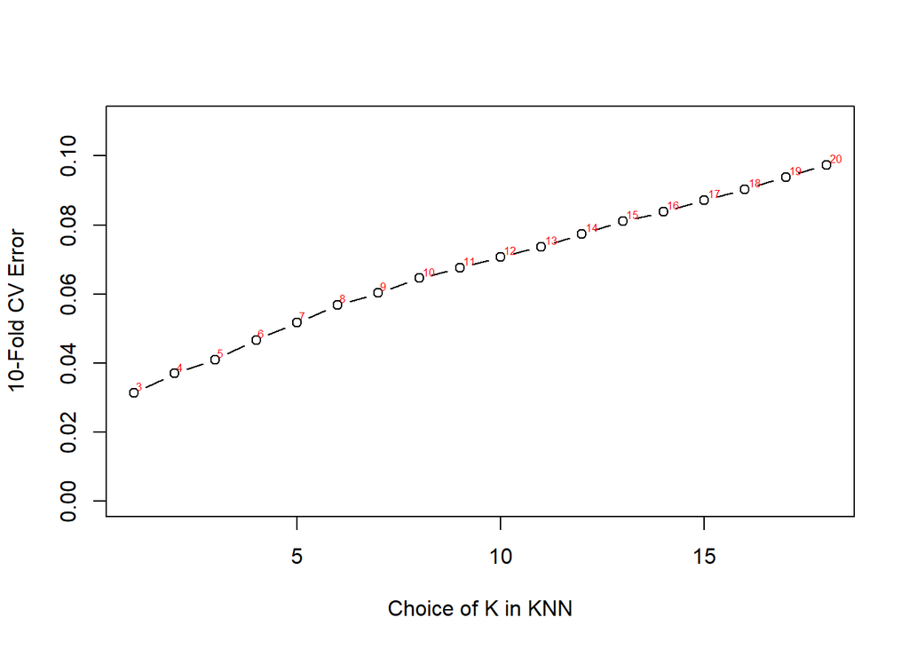

```r
plot(avg_mse_knn[3:20], ylim=c(0.0,0.11),xlab="Choice of K in KNN", ylab="10-Fold CV Error", type="b")
textxy(c(1:20), c(avg_mse_knn[3:20]),labs=c(3:20), col = "red")
```

```r
fit15=avg_mse_knn[3]
```

The KNN regression for K=3 yields the lowest 10-fold CV error of 0.0313274 Although the CV Error is less than the CV error of the full OLS model of 0.0421253, KNN provides no information on which predictors are significant, nor does it achieve our goal of reducing the number of variables to understand a smaller subset of predictors that define HFI.

```r
rm(gam1, polyfit, polyfit2, polyfit3, polyfit4, polyfit5, polyfit6, pred2, preds, se.bands, test_res, test_set, train_res, train_set, x, avg_mse_knn, CVerror, CVerror.poly, CVerrorGAM, CVerrorSpline, ef_trade_regulatory.grid, ef_trade_regulatorylims, i, k, kfold.number, mse_list_knn, Rsquared.smoothspline, string.to.print, testMSE.smoothspline, top_k)
```

# 5. Tree-Based Methods

## 5.1 Standard Regression Tree

```r
##Fitting a regression tree:
tree1= tree(hf_score~.,hfi.combined)
tree.hfi= cv.tree(tree1, K = 10)
summary(tree1)
```

```
##
## Regression tree:
## tree(formula = hf_score ~ ., data = hfi.combined)
## Variables actually used in tree construction:
## [1] "pf_expression_control"   "ef_trade_movement_visit"
## [3] "ef_trade_tariffs_mean"   "ef_legal_military"
## [5] "ef_trade_regulatory"     "ef_legal_gender"
## [7] "ef_money_currency"       "pf_ss_homicide"
## [9] "ef_legal_courts"
## Number of terminal nodes:  13
## Residual mean deviance:  0.1507 = 194.8 / 1292
## Distribution of residuals:
##      Min.   1st Qu.    Median      Mean   3rd Qu.      Max.
## -1.701000 -0.223400  0.001728  0.000000  0.216100  1.483000
```

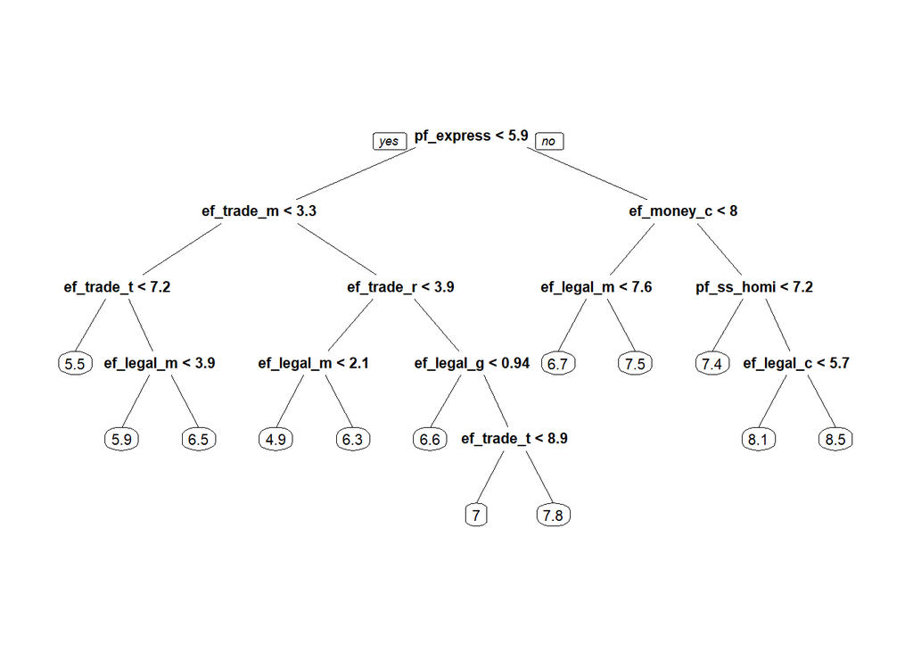

```r
tree2= rpart(hf_score~.,hfi.combined)
prp(tree2)
text(tree1, pretty =1)
```

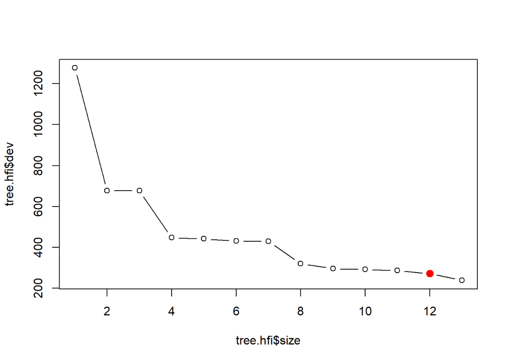

```r
plot(tree.hfi$size,tree.hfi$dev, type = "b")
points(12, tree.hfi$dev[tree.hfi$size[12]], col = "red", cex = 2, pch = 20)
```

```r
tree.hfi$dev[tree.hfi$size[12]]
```

```
## [1] 271.5083
```

```r
fit16=.1643
```

## 5.2 Standard Regression Tree with Pruning

```r
pruned.tree =prune.tree(tree1, best=8)
summary(pruned.tree)
```

```
##
## Regression tree:
## snip.tree(tree = tree1, nodes = c(15L, 10L, 6L, 23L, 9L))
## Variables actually used in tree construction:
## [1] "pf_expression_control"   "ef_trade_movement_visit"
## [3] "ef_trade_tariffs_mean"   "ef_trade_regulatory"
## [5] "ef_legal_gender"         "ef_money_currency"
## [7] "pf_ss_homicide"
## Number of terminal nodes:  8
## Residual mean deviance:  0.2157 = 279.8 / 1297
## Distribution of residuals:
##      Min.   1st Qu.    Median      Mean   3rd Qu.      Max.
## -1.701000 -0.289700 -0.004833  0.000000  0.284700  1.569000
```

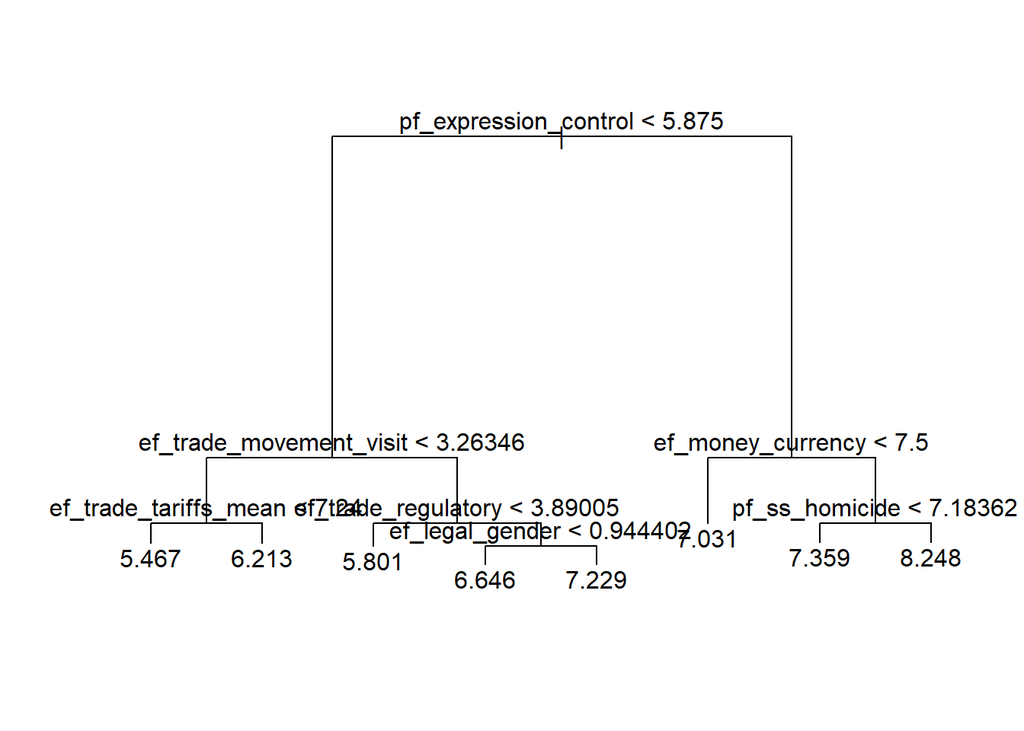

```r
plot(pruned.tree)
text(pruned.tree, pretty =1)
```

```r
fit17=.2213
```

## 5.3 Bagging and Random Forests

```r
set.seed(111)
rf.train= hfi.combined.train[ ,-40]
rf.test=hfi.combined.test[,-40]
rf.resp.train <- hfi.combined.train[, 40]
rf.resp.test <- hfi.combined.test[, 40]
bag= randomForest(rf.train, y=rf.resp.train, xtest=rf.test, ytest=rf.resp.test, mtry=(ncol(hfi.combined)-1), ntree=1000, importance=TRUE)
```

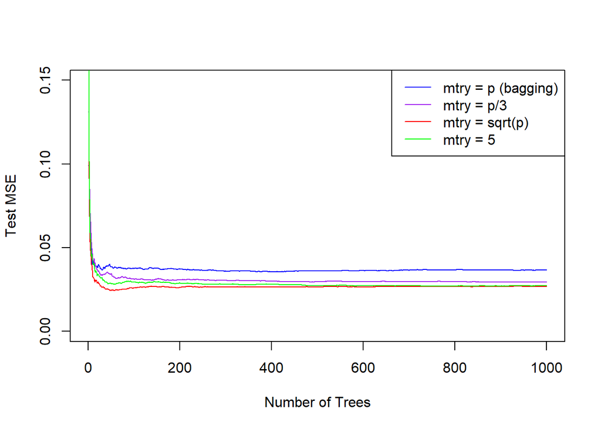

```r
rf1= randomForest(rf.train, y=rf.resp.train, xtest=rf.test, ytest=rf.resp.test, mtry=((ncol(hfi.combined)-1)/3), ntree=1000, importance=TRUE)
rf2= randomForest(rf.train, y=rf.resp.train, xtest=rf.test, ytest=rf.resp.test, mtry=sqrt((ncol(hfi.combined)-1)), ntree=1000, importance=TRUE)
rf3= randomForest(rf.train, y=rf.resp.train, xtest=rf.test, ytest=rf.resp.test, mtry=5, ntree=1000, importance=TRUE)

plot(1:1000, bag$test$mse, col = "blue", type = "l", xlab = "Number of Trees", ylab = "Test MSE", ylim = c(0, .15))
lines(1:1000, rf1$test$mse, col = "purple", type = "l")
lines(1:1000, rf2$test$mse, col = "red", type = "l")
lines(1:1000, rf3$test$mse, col = "green", type = "l")
legend("topright", c("mtry = p (bagging)", "mtry = p/3", "mtry = sqrt(p)", "mtry = 5"), col = c("blue", "purple", "red", "green"), cex = 1, lty = 1)
```

```r
which.min(bag$test$mse)
```

```
## [1] 409
```

```r
fit18=bag$test$mse[which.min(bag$test$mse)]
which.min(rf1$test$mse)
```

```
## [1] 994
```

```r
fit19=rf1$test$mse[which.min(rf1$test$mse)]
```

```r
importance(rf1)
```

```
##                                     %IncMSE IncNodePurity
## pf_ss_homicide                    32.310894    23.5301567
## pf_ss_disappearances_disap        13.461751     1.5939488
## pf_ss_disappearances_violent      12.828011     2.2940053
## pf_ss_disappearances_fatalities   14.367975     2.9575436
## pf_ss_disappearances_injuries     10.964362     1.8052015
## pf_movement_domestic              14.486536     8.3702042
## pf_movement_foreign               17.642026    10.1573596
## pf_religion_harassment            16.858545     2.6474688
## pf_religion_restrictions          23.681207     3.7335225
## pf_expression_killed               6.893584     0.8553081
## pf_expression_jailed               9.485544     1.3464213
## pf_expression_influence           27.795831   143.6166668
## pf_expression_control             37.894402   193.7902804
## pf_identity_sex_male              19.458382     7.6632036
## pf_identity_sex_female            16.230576     8.7537451
## ef_government_consumption         24.244496     4.5641542
## ef_legal_courts                   37.688682    13.1365603
## ef_legal_military                 27.752094    62.2478156
## ef_legal_enforcement              31.547522    14.2530996
## ef_legal_gender                   42.317045    69.9557783
## ef_money_growth                   13.640629     3.8665923
## ef_money_sd                       22.182662    19.3899277
## ef_money_inflation                16.099112     6.0654423
## ef_money_currency                 23.587463    22.9821901
## ef_trade_tariffs_mean             35.269511    96.6782158
## ef_trade_tariffs_sd               25.537675     8.1607987
## ef_trade_tariffs                  25.293385    20.3111186
## ef_trade_regulatory_compliance    27.509297    79.3495427
## ef_trade_regulatory               29.372470    87.6142223
## ef_trade_black                     8.926378     1.5846020
## ef_trade_movement_capital         23.910369    22.4117744
## ef_trade_movement_visit           37.573347    31.8375666
## ef_regulation_credit_private      15.962714     2.9367203
## ef_regulation_credit              31.809478    31.3129537
## ef_regulation_labor_minwage       22.052370     2.9796971
## ef_regulation_labor_hours         15.631035     1.4600101
## ef_regulation_labor_conscription  19.418839     2.7847791
## ef_regulation_business_start      23.923149     9.3398803
## ef_regulation_business_compliance 33.479358    11.5645188
```